# Web page Phishing Detection

Thomas Fernandes, Yassine Ouerghi, Vanessa Kenniche, Mario Miron Ramos

2023-11-09

L’étude vise à prédire la légitimité des sites web en utilisant diverses techniques de machine learning. Le phénomène du phishing consiste en des tentatives de fraude en ligne par le biais de sites web frauduleux imitant des sites légitimes.

La variable que nous cherchons à prédire est “status”, qui indique si un site web est légitime ou potentiellement frauduleux (phishing). Pour ce faire, nous disposons d’un ensemble de données équilibré de 87 variables explicatives différentes, chacune fournissant des informations sur divers aspects de 11430 sites web différents. Ces données incluent 56 variables basées sur la structure, 24 extraites du contenu des pages web correspondantes, 7 obtenues par des requêtes auprès de services externes.

# 1. Présentation des données

Avant de commencer les différentes modélisations, nous allons regarder comment se structurent nos données.

## 1.1. Corrélation entre les variables quantitatives

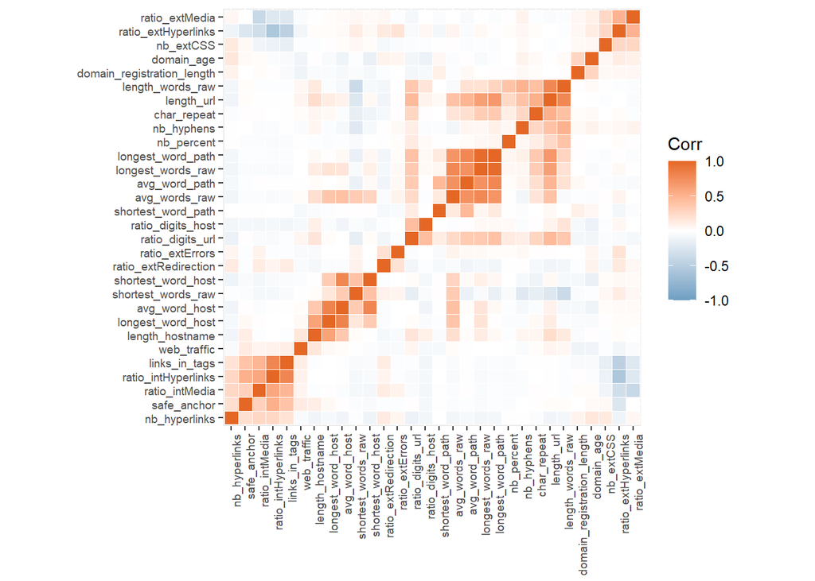

```r
df_present <- df

#Extraire les variables qualitatives
v_quali <- vector("logical", length = ncol(df_present) - 1)
for (i in 2:ncol(df_present)) {
  v_quali[[i]] <- (length(unique(df_present[[i]])) / sum(!is.na(df_present[[i]]))) < 0.002
}

num_cols <- character()
cat_cols <- character()

for (i in 1:length(v_quali)) {
  if (!v_quali[[i]]) {
    num_cols <- c(num_cols, names(df_present)[i])
  } else {
    cat_cols <- c(cat_cols, names(df_present)[i])
  }
}

corr <- cor(df_present[num_cols])

ggcorrplot(
  corr,
  hc.order = TRUE,
  type = "full",
  outline.color = "white",
  ggtheme = ggplot2::theme_gray,
  colors = c("#6D9EC1", "white", "#E46726"),
  show.diag = TRUE,
  tl.cex = 7,
  tl.srt = 90
)
```

Comme on s’y attendait, on remarque que de nombreuses variables sont corrélées entre elles. C’est le cas par exemple de longest_word_path et de avg_word_path.

On fait un boxplot de toutes les variables

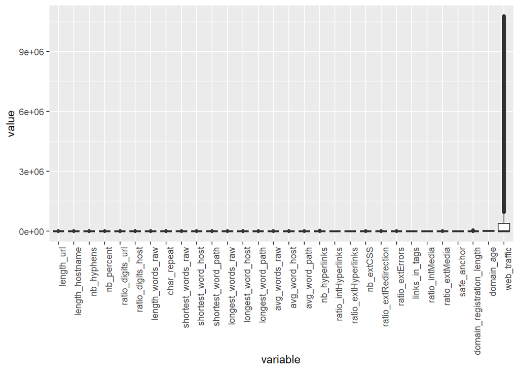

```r
ggplot(data = melt(df_present[, num_cols]), aes(x = variable, y = value)) +
  geom_boxplot() +
  theme(axis.text.x = element_text(angle = 90, hjust = 1))
```

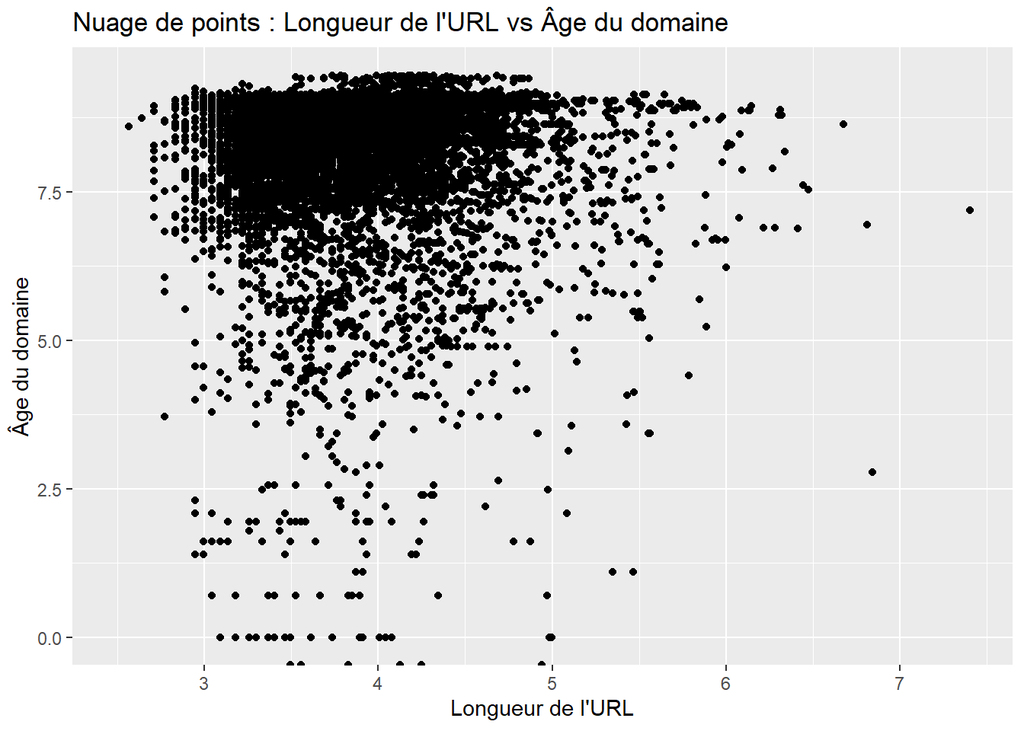

```r
attach(df)

ggplot(df, aes(x = log(length_url), y = log(domain_age))) +
  geom_point() +
  labs(x = "Longueur de l'URL", y = "Âge du domaine") +
  ggtitle("Nuage de points : Longueur de l'URL vs Âge du domaine")
```

```r
max(domain_age)
```

```
## [1] 12874
```

```r
min(domain_age)
```

```
## [1] -12
```

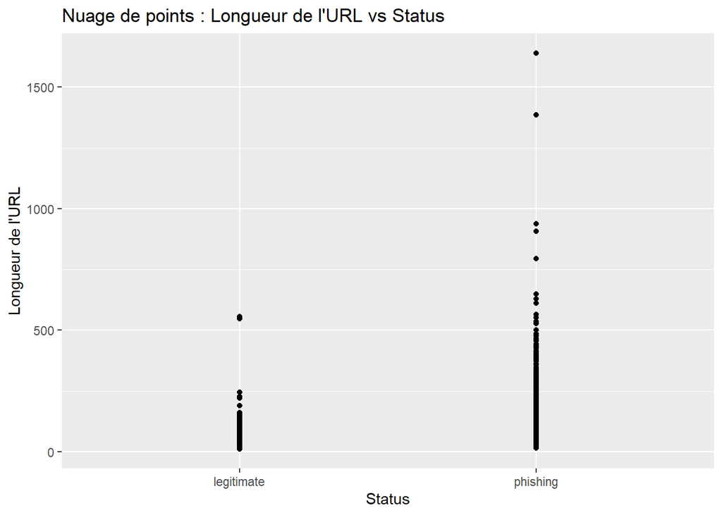

```r
# Nuage de point y = longueur url, x = status
ggplot(df, aes(x = status, y = length_url)) +
  geom_point() +
  labs(x = "Status", y = "Longueur de l'URL") +
  ggtitle("Nuage de points : Longueur de l'URL vs Status")
```

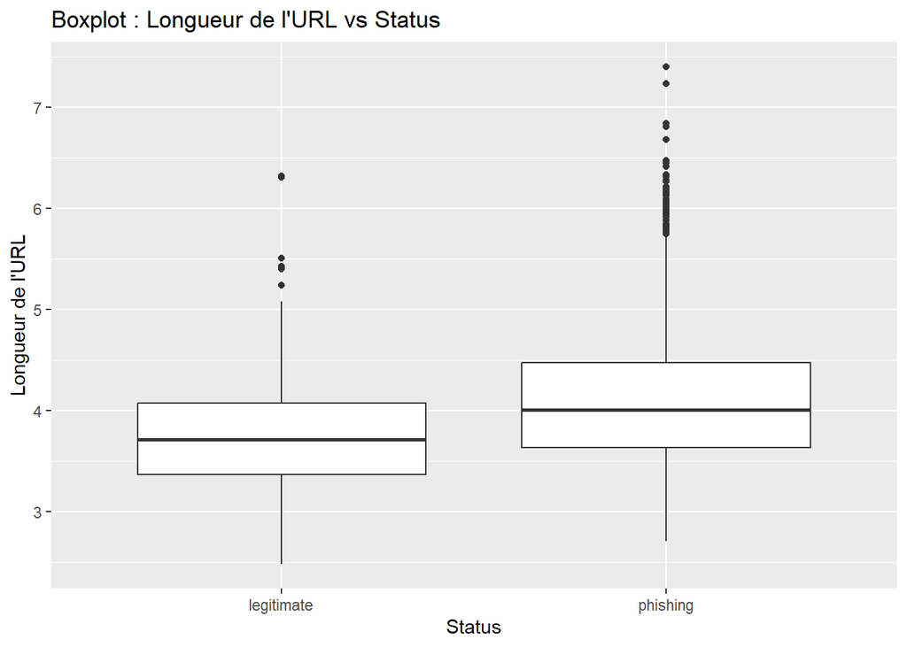

```r
# Boxplot
ggplot(df, aes(x = status, y = log(length_url))) +
  geom_boxplot() +
  labs(x = "Status", y = "Longueur de l'URL") +
  ggtitle("Boxplot : Longueur de l'URL vs Status")
```

## 1.2. Moyenne par statut

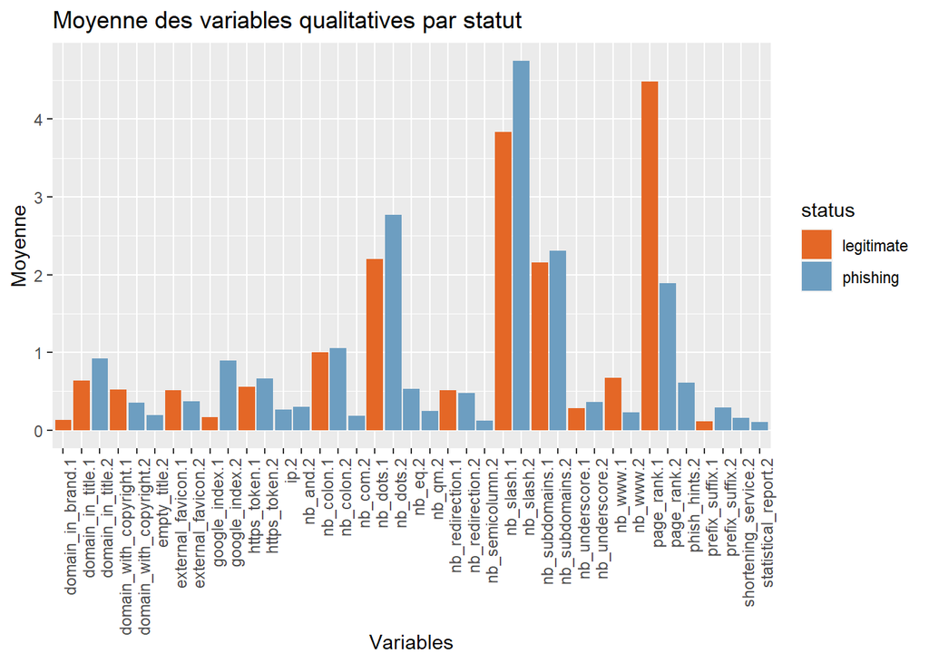

```r
mean_by_status <- function(df, col_name) {
  df %>%
    group_by(status) %>%
    summarise(mean_value = mean(.data[[col_name]], na.rm = TRUE))
}
mean_values_list_cat <- list()

for (col in cat_cols) {
  mean_values_list_cat[[col]] <- mean_by_status(df_present, col)
}

mean_values_df_cat <- do.call(rbind, mean_values_list_cat)
mean_values_df_cat$col_names <- rownames(mean_values_df_cat)

mean_values_df_cat <- mean_values_df_cat[mean_values_df_cat$mean_value > 0.1 | mean_values_df_cat$mean_value < -0.1,]
mean_values_df_cat <- mean_values_df_cat[!is.na(mean_values_df_cat$mean_value), ]

ggplot(mean_values_df_cat, aes(x = col_names, y = mean_value, fill = status)) +
  geom_bar(stat = "identity", position = "dodge") +
  labs(x = "Variables", y = "Moyenne", title = "Moyenne des variables qualitatives par statut") +
  theme(axis.text.x = element_text(angle = 90, hjust = 1)) +
  scale_fill_manual(values = c("#E46726", "#6D9EC1"))
```

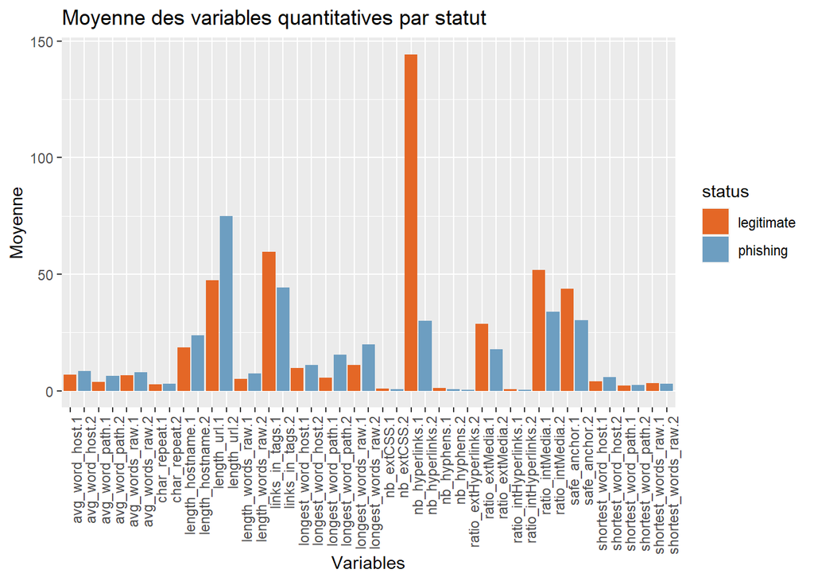

```r
mean_values_list_num <- list()

for (col in num_cols) {
  if (col != "web_traffic" && col != "domain_age" && col != "domain_registration_length") {
    mean_values_list_num[[col]] <- mean_by_status(df_present, col)
  }
}

mean_values_df_num <- do.call(rbind, mean_values_list_num)
mean_values_df_num$col_names <- rownames(mean_values_df_num)

mean_values_df_num <- mean_values_df_num[mean_values_df_num$mean_value > 0.3 | mean_values_df_num$mean_value < -0.3,]
mean_values_df_num <- mean_values_df_num[!is.na(mean_values_df_num$mean_value), ]

ggplot(mean_values_df_num, aes(x = col_names, y = mean_value, fill = status)) +
  geom_bar(stat = "identity", position = "dodge") +
  labs(x = "Variables", y = "Moyenne", title = "Moyenne des variables quantitatives par statut") +
  theme(axis.text.x = element_text(angle = 90, hjust = 1)) +
  scale_fill_manual(values = c("#E46726", "#6D9EC1"))
```

Le nombre d’hyperlien semble être la variable quantitative qui influe le plus.

# 2. Modélisation

## 2.1. Préparation du jeu de données

On sépare le jeu de données en un échantillon d’entraînement et un échantillon test, qui seront les mêmes pour tous les modèles.

```r
set.seed(123)
indxTrain <- createDataPartition(df$status, p = 0.75, list = FALSE)
DTrain <- df[indxTrain, ]
DTest <- df[-indxTrain, ]
```

## 2.2. Variable de controle

```r
ctrl <- trainControl(method = "cv", number = 5)
```

## 2.3. Entrainement

### KNN

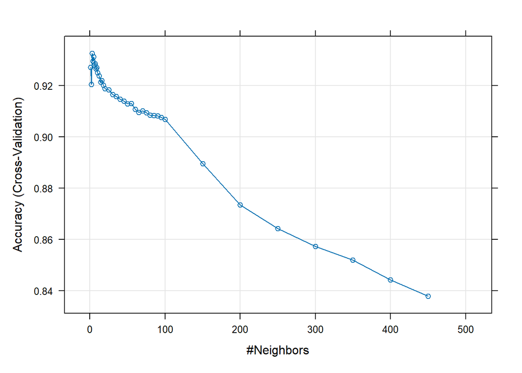

```r
set.seed(123)

k <- c(1:10, seq(12, 19, by = 2), seq(20, 99, by = 5), seq(100, 500, by = 50))

#fit.knn.cv <- train(status ~ .,data = DTrain,method = "knn",trControl = ctrl,tuneGrid = expand.grid(k = k),preProcess = c("center", "scale"),na.action = na.omit)
load("C:/Users/thoma/Desktop/Github/Web-page-Phishing-Detection/fit.knn.cv.RDATA")
plot(fit.knn.cv)
```

```r
bestK <- fit.knn.cv$bestTune$k
print(fit.knn.cv$results)
```

```
##      k  Accuracy     Kappa  AccuracySD     KappaSD
## 1    1 0.9272210 0.8544423 0.007037996 0.014075344
## 2    2 0.9205740 0.8411486 0.008217546 0.016433645
## 3    3 0.9327036 0.8654076 0.004973536 0.009946071
## 4    4 0.9295545 0.8591097 0.005333699 0.010665375
## 5    5 0.9313040 0.8626088 0.004796734 0.009591570
## 6    6 0.9280380 0.8560767 0.006182806 0.012363033
## 7    7 0.9286210 0.8572428 0.007154438 0.014305675
## 8    8 0.9265216 0.8530439 0.007300813 0.014598271
## 9    9 0.9269884 0.8539780 0.008982349 0.017960843
## 10  10 0.9251224 0.8502460 0.007676528 0.015348829
## 11  12 0.9238392 0.8476795 0.010073711 0.020143809
## 12  14 0.9213899 0.8427811 0.009162384 0.018321369
## 13  16 0.9219728 0.8439468 0.007963850 0.015925124
## 14  18 0.9202238 0.8404491 0.010435372 0.020866929
```

[output cut: 25 more lines]

### Regression logistique

```r
#Sans AIC
fit.lr <- train(status ~ .,
                data = DTrain,
                method = "glm",
                trControl = ctrl,
                na.action = na.omit)
print(varImp(fit.lr))
```

```
## glm variable importance
##
##   only 20 most important variables shown (out of 81)
##
##                            Overall
## google_index                100.00
## page_rank                    81.32
## nb_www                       56.29
## phish_hints                  52.56
## domain_age                   34.17
## nb_hyperlinks                32.68
## shortening_service           32.05
## longest_words_raw            29.62
## ratio_digits_host            26.20
## length_hostname              25.31
## nb_hyphens                   24.42
## domain_in_title              23.75
## nb_underscore                23.70
## https_token                  22.65
## domain_registration_length   22.34
## ratio_extHyperlinks          21.37
## ratio_extRedirection         20.95
## ratio_extMedia               19.75
## avg_words_raw                19.56
## nb_space                     19.21
```

```r
#Avec AIC
#fit.lr.aic <- train(status ~ ., data = DTrain, method = "glmStepAIC", trControl = ctrl, na.action = na.omit)
load("C:/Users/thoma/Desktop/Github/Web-page-Phishing-Detection/fit.lr.aic.RDATA")
```

On extrait l’importance des variables. Elle sera utile par la suite.

```r
importance <- varImp(fit.lr)$importance
variable_names <- rownames(importance)
importance_values <- importance$Overall
variable_indexes <- match(variable_names, names(DTrain))
important_vars_df <- data.frame(
  Variable = variable_names,
  Importance = importance_values,
  Index = variable_indexes
)
important_vars_df_sorted <- important_vars_df[order(important_vars_df$Importance, decreasing = TRUE), ]
```

### NB

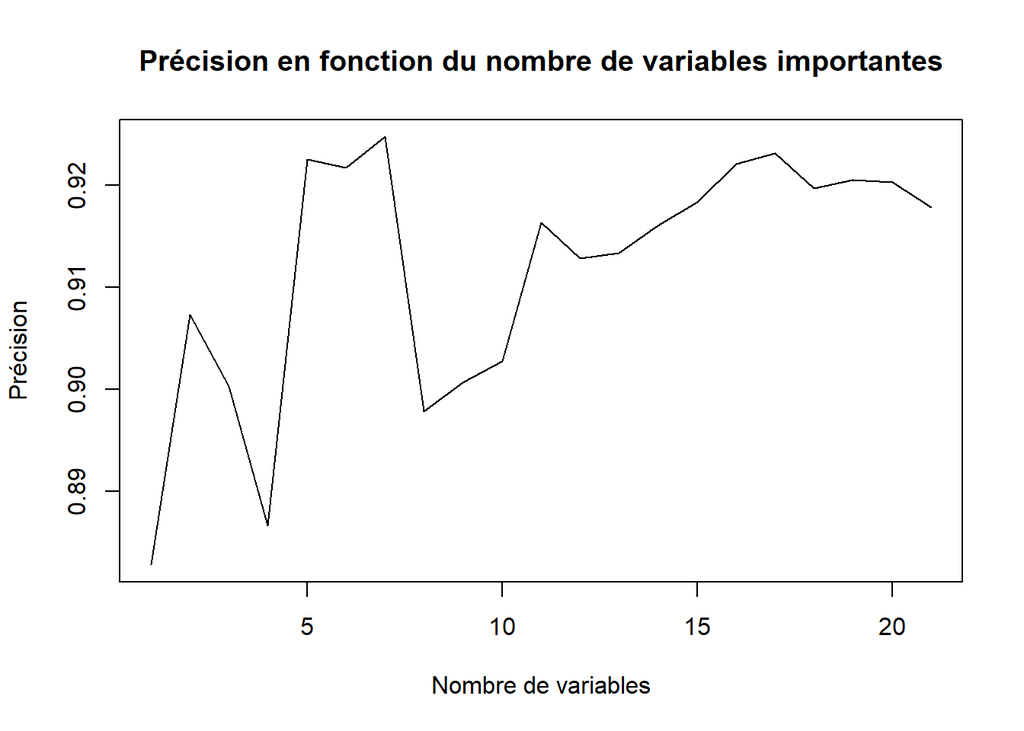

```r
# accuracies_nb <- numeric()
# best_accuracy_nb <- 0
# best_combination_nb <- NULL
#
# for (i in 2:25) {
#   variable_names_nb <- names(DTrain)[important_vars_df_sorted$Index[1:i]]
#   fit.nb_temp <- train(status ~ .,
#                        data = DTrain[, c("status", variable_names_nb)],
#                        method = "nb",
#                        trControl = ctrl)
#   model_accuracy_nb <- max(fit.nb_temp$results$Accuracy)
#   accuracies_nb[i - 1] <- model_accuracy_nb
#
#   if (model_accuracy_nb > best_accuracy_nb) {
#     best_accuracy_nb <- model_accuracy_nb
#     best_combination_nb <- variable_names_nb
#   }
# }
#
# fit.nb <- train(status ~ .,
#                 data = DTrain[, c("status", best_combination_nb)],
#                 method = "nb",
#                 trControl = ctrl)
load("C:/Users/thoma/Desktop/Github/Web-page-Phishing-Detection/fit.nb.RDATA")
plot(accuracies_nb, type = "l", xlab = "Nombre de variables", ylab = "Précision", main = "Précision en fonction du nombre de variables importantes")
```

### LDA

```r
fit.lda = train(status ~ .,
                data = DTrain[, -c(9, 60, 62, 64, 69, 72)],
                method="lda",
                trControl=ctrl)
```

### QDA

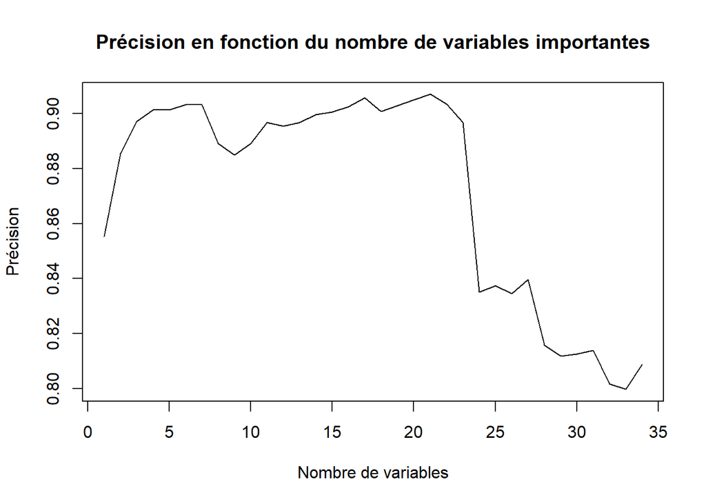

```r
# accuracy_qda <- numeric()
# best_accuracy_qda <- 0
# best_combination_qda <- NULL
#
# for (i in 2:35) {
#   variable_names <- names(DTrain)[important_vars_df_sorted$Index[1:i]]
#
#   fit.qda <- train(status ~ .,
#                    data = DTrain[, c("status", variable_names)],
#                    method = "qda",
#                    trControl = ctrl)
#
#   model_accuracy <- max(fit.qda$results$Accuracy)
#
#   accuracy_qda[i - 1] <- model_accuracy
#
#   if (model_accuracy > best_accuracy_qda) {
#     best_accuracy_qda <- model_accuracy
#     best_combination_qda <- variable_names
#   }
# }
load("C:/Users/thoma/Desktop/Github/Web-page-Phishing-Detection/fit.qda.RDATA")
plot(accuracies_qda, type = "l", xlab = "Nombre de variables", ylab = "Précision", main = "Précision en fonction du nombre de variables importantes")
```

### SVM - Séparateur Linéaire

```r
# svmGrid_lin <- seq(0.0001, 0.01 ,by = 0.001)
# best_accuracies_svm <- numeric()
# best_accuracy_svm <- 0
# best_combination_svm <- NULL
# best_C_svm <- NULL
#
# for (i in 2:20) {
#   variable_names_svm <- names(DTrain)[important_vars_df_sorted$Index[1:i]]
#   fit.Lin.svm <- train(status ~ .,
#                        data = DTrain[, c("status", variable_names_svm)],
#                        method = "svmLinear",
#                        type = "C-svc",
#                        trControl = ctrl,
#                        tuneGrid = data.frame(.C = svmGrid_lin))
#   max_accuracy <- max(fit.Lin.svm$results$Accuracy)
#   max_C <- fit.Lin.svm$bestTune$.C
#
#   best_accuracies_svm[i - 1] <- max_accuracy
#
#   if (max_accuracy > best_accuracy_svm) {
#     best_accuracy_svm <- max_accuracy
#     best_combination_svm <- variable_names_svm
#     best_C_svm <- max_C
#   }
# }

load("C:/Users/thoma/Desktop/Github/Web-page-Phishing-Detection/fit.Lin.svm.RDATA")
fit.Lin.svm$bestTune
```

|  | C |
| --- | --- |
| 1 | 1e-04 |

### SVM - Séparateur Quadratique

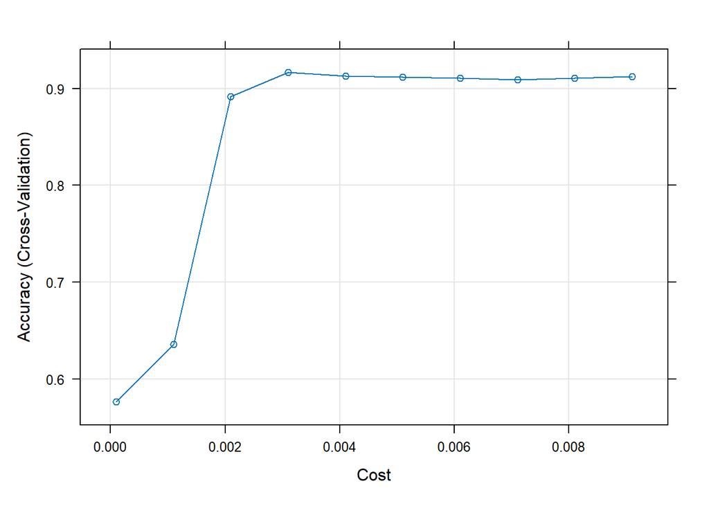

```r
#Noyau Radial
# svmGrid_quad <- expand.grid(.C = seq(0.0001, 0.01, by = 0.001), .sigma = seq(0.0001, 0.01, by = 0.001))
# best_accuracies_svm_radial <- numeric()
# best_accuracy_svm_radial <- 0
# best_combination_svm_radial <- NULL
# best_params_svm_radial <- NULL
#
# for (i in 2:20) {
#   variable_names_svm_radial <- names(DTrain)[important_vars_df_sorted$Index[1:i]]
#   fit.Quad.svm <- train(status ~ .,
#                         data = DTrain[, c("status", variable_names_svm_radial)],
#                         method = "svmRadial",
#                         type = "C-svc",
#                         trControl = ctrl_temp,
#                         tuneGrid = svmGrid_quad)
#
#   max_accuracy_radial <- max(fit.Quad.svm$results$Accuracy)
#   max_params_radial <- fit.Quad.svm$bestTune
#
#   best_accuracies_svm_radial[i - 1] <- max_accuracy_radial
#
#   if (max_accuracy_radial > best_accuracy_svm_radial) {
#     best_accuracy_svm_radial <- max_accuracy_radial
#     best_combination_svm_radial <- variable_names_svm_radial
#     best_params_svm_radial <- max_params_radial
#   }
# }
load("C:/Users/thoma/Desktop/Github/Web-page-Phishing-Detection/fit.Quad.svm.RDATA")
plot(fit.Quad.svm)
```

```r
fit.Quad.svm$bestTune
```

|  | sigma | C |
| --- | --- | --- |
| 4 | 0.1 | 0.0031 |

## Prédictions

### KNN

```r
set.seed(123)
predictionsBestK <- predict(fit.knn.cv, newdata = DTest)
confusionMatrixBestK <- confusionMatrix(predictionsBestK, DTest$status)
print(confusionMatrixBestK$overall['Accuracy'])
```

```
##  Accuracy
## 0.9488796
```

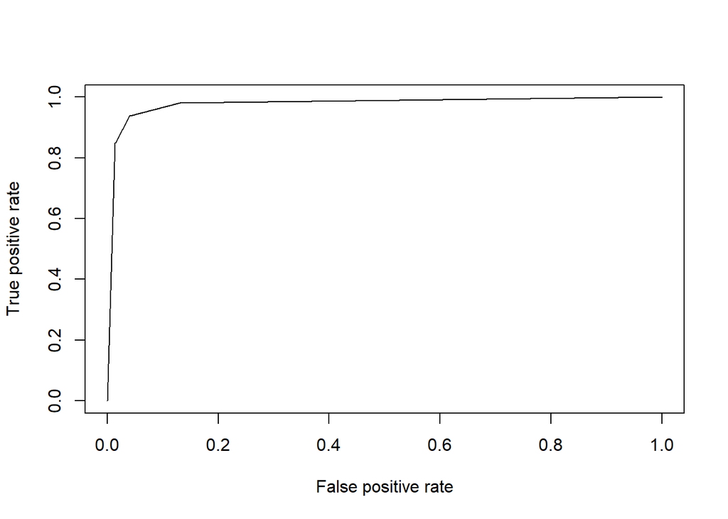

```r
set.seed(123)
predictionsBestK <- predict(fit.knn.cv, newdata = DTest, type = "prob")

pred.knn <- prediction(predictionsBestK[,2], DTest$status)
perf.knn <- performance(pred.knn, "tpr", "fpr")
plot(perf.knn)
```

```r
auc.knn <- performance(pred.knn, "auc")@y.values[[1]]
```

### Regression logistique

```r
class.lr <- predict(fit.lr, newdata = DTest)
print(varImp(fit.lr))
```

```
## glm variable importance
##
##   only 20 most important variables shown (out of 81)
##
##                            Overall
## google_index                100.00
## page_rank                    81.32
## nb_www                       56.29
## phish_hints                  52.56
## domain_age                   34.17
## nb_hyperlinks                32.68
## shortening_service           32.05
## longest_words_raw            29.62
## ratio_digits_host            26.20
## length_hostname              25.31
## nb_hyphens                   24.42
## domain_in_title              23.75
## nb_underscore                23.70
## https_token                  22.65
## domain_registration_length   22.34
## ratio_extHyperlinks          21.37
## ratio_extRedirection         20.95
## ratio_extMedia               19.75
## avg_words_raw                19.56
## nb_space                     19.21
```

```r
class.lr.aic <- predict(fit.lr.aic, newdata = DTest)

confusionMatrixLR <- confusionMatrix(class.lr, DTest$status)
confusionMatrixLRAIC <- confusionMatrix(class.lr.aic, DTest$status)
print(confusionMatrixLR$overall['Accuracy'])
```

```
##  Accuracy
## 0.9464286
```

```r
print(confusionMatrixLRAIC$overall['Accuracy'])
```

```
##  Accuracy
## 0.9457283
```

```r
class.lr <- predict(fit.lr, newdata = DTest, type = "prob")
class.lr.aic <- predict(fit.lr.aic, newdata = DTest, type = "prob")

pred.lr <- prediction(class.lr[,2], DTest$status)
perf.lr <- performance(pred.lr, "tpr", "fpr")
auc.lr <- performance(pred.lr, "auc")@y.values[[1]]
```

### NB

```r
#Accuracy
class.nb <- predict(fit.nb, newdata = DTest)
confusionMatrixNB <- confusionMatrix(class.nb, DTest$status)
print(confusionMatrixNB$overall['Accuracy'])
```

```
##  Accuracy
## 0.9303221
```

```r
pred.nb = predict(fit.nb, newdata=DTest[,c(best_combination_nb)], type = "prob")

pred.nb <- prediction(pred.nb[,2], DTest$status)
perf.nb <- performance(pred.nb, "tpr", "fpr")
auc.nb <- performance(pred.nb, "auc")@y.values[[1]]
```

### LDA

```r
class.lda <- predict(fit.lda, newdata = DTest)
confusionMatrixLDA <- confusionMatrix(class.lda, DTest$status)
print(confusionMatrixLDA$overall['Accuracy'])
```

```
##  Accuracy
## 0.9327731
```

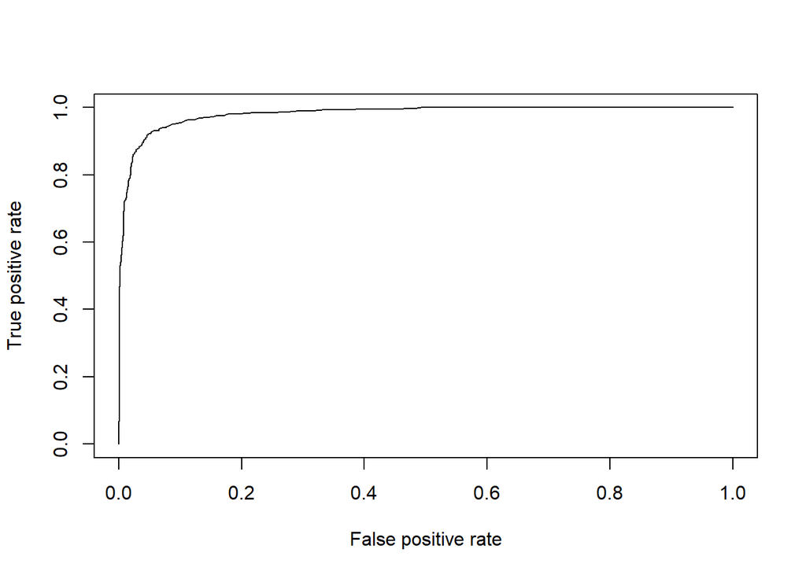

```r
pred.lda = predict(fit.lda, newdata=DTest[,-c(9, 60, 62, 64, 69, 72, 88)], type = "prob")
pred.lda <- prediction(pred.lda[,2], DTest$status)
perf.lda <- performance(pred.lda, "tpr", "fpr")
plot(perf.lda)
```

```r
auc.lda <- performance(pred.lda, "auc")@y.values[[1]]
```

### QDA

```r
class.qda <- predict(fit.qda, newdata = DTest)
confusionMatrixQDA <- confusionMatrix(class.qda, DTest$status)
print(confusionMatrixQDA$overall['Accuracy'])
```

```
##  Accuracy
## 0.8067227
```

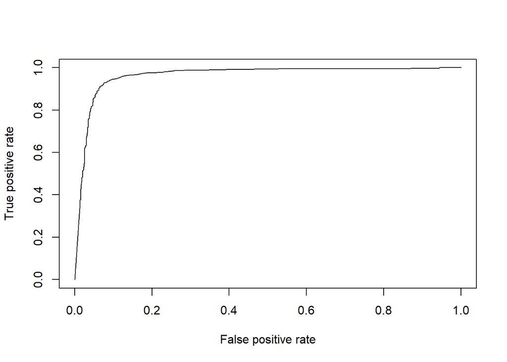

```r
pred.qda = predict(fit.qda, newdata=DTest[, best_combination_qda], type = "prob")
pred.qda <- prediction(pred.qda[,2], DTest$status)
perf.qda <- performance(pred.qda, "tpr", "fpr")
plot(perf.qda)
```

```r
auc.qda <- performance(pred.qda, "auc")@y.values[[1]]
```

### SVM - Séparateur Linéaire

```r
class.Lin.svm <- predict(fit.Lin.svm, newdata = DTest)
confusionMatrixLinSVM <- confusionMatrix(class.Lin.svm, DTest$status)
print(confusionMatrixLinSVM$overall['Accuracy'])
```

```
##  Accuracy
## 0.9156162
```

### SVM - Séparateur Quadratique

#### Noyau Radial

```r
class.Quad.svm <- predict(fit.Quad.svm, newdata = DTest)
confusionMatrixQuadSVM <- confusionMatrix(class.Quad.svm, DTest$status)
print(confusionMatrixQuadSVM$overall['Accuracy'])
```

```
##  Accuracy
## 0.9194678
```

## Comparaison des modèles

On fait un dataframe récapitulatif avec en ligne les différents modèles et en colonne on aura accuracy, sensibilité, spécificité et AUC.

Pour l’instant, on ne fait que pour KNN, logistique, NB, LDA et QDA.

```r
models <- c("KNN", "Logistique", "NB", "LDA", "QDA")
accuracy <- c(confusionMatrixBestK$overall['Accuracy'], confusionMatrixLR$overall['Accuracy'], confusionMatrixNB$overall['Accuracy'], confusionMatrixLDA$overall['Accuracy'], confusionMatrixQDA$overall['Accuracy'])
sensibilite <- c(confusionMatrixBestK$byClass['Sensitivity'], confusionMatrixLR$byClass['Sensitivity'], confusionMatrixNB$byClass['Sensitivity'], confusionMatrixLDA$byClass['Sensitivity'], confusionMatrixQDA$byClass['Sensitivity'])
specificite <- c(confusionMatrixBestK$byClass['Specificity'], confusionMatrixLR$byClass['Specificity'], confusionMatrixNB$byClass['Specificity'], confusionMatrixLDA$byClass['Specificity'], confusionMatrixQDA$byClass['Specificity'])
auc <- c(auc.knn, auc.lr, auc.nb, auc.lda, auc.qda)

df_models <- data.frame(models, accuracy, sensibilite, specificite, auc)
df_models
```

| models | accuracy | sensibilite | specificite | auc |
| --- | --- | --- | --- | --- |
| KNN | 0.9488796 | 0.9586835 | 0.9390756 | 0.9769111 |
| Logistique | 0.9464286 | 0.9460784 | 0.9467787 | 0.9852774 |
| NB | 0.9303221 | 0.9579832 | 0.9026611 | 0.9805765 |
| LDA | 0.9327731 | 0.9257703 | 0.9397759 | 0.9813622 |
| QDA | 0.8067227 | 0.9691877 | 0.6442577 | 0.9631335 |

On fait 1 graphqiue avec toutes les courbes ROC et on affiche les valeurs AUC.

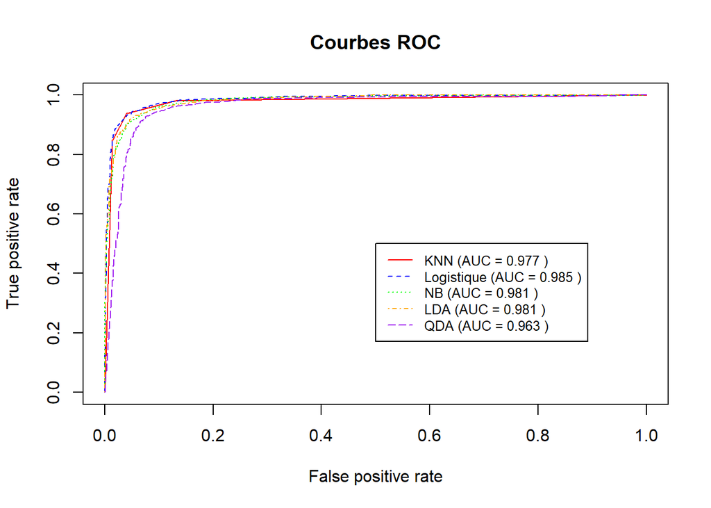

```r
legend_labels <- c(
    paste("KNN (AUC =", round(auc.knn, 3), ")"),
    paste("Logistique (AUC =", round(auc.lr, 3), ")"),
    paste("NB (AUC =", round(auc.nb, 3), ")"),
    paste("LDA (AUC =", round(auc.lda, 3), ")"),
    paste("QDA (AUC =", round(auc.qda, 3), ")")
)

plot(perf.knn, col = "red", main = "Courbes ROC", lty = 1)
plot(perf.lr, col = "blue", add = TRUE, lty = 2)
plot(perf.nb, col = "green", add = TRUE, lty = 3)
plot(perf.lda, col = "orange", add = TRUE, lty = 4)
plot(perf.qda, col = "purple", add = TRUE, lty = 5)

legend(0.5, 0.5, legend = legend_labels, col = c("red", "blue", "green", "orange", "purple"), lty = c(1, 2, 3, 4, 5), cex = 0.8)
```

On fait le même graphique mais en zoom sur la partie gauche.

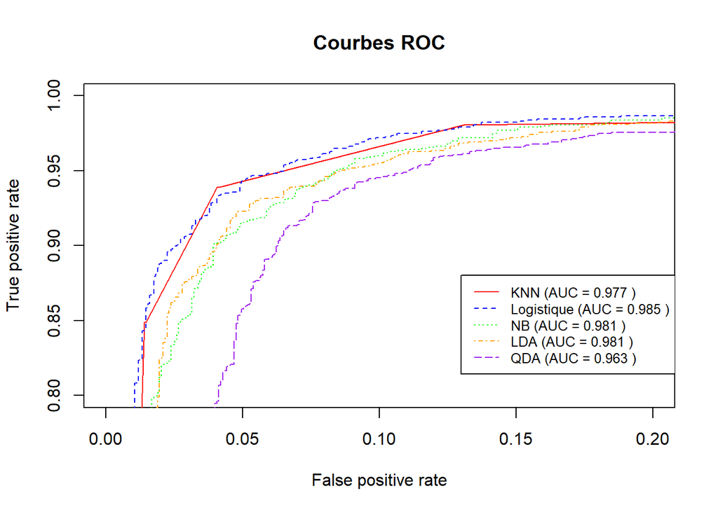

```r
legend_labels <- c(
    paste("KNN (AUC =", round(auc.knn, 3), ")"),
    paste("Logistique (AUC =", round(auc.lr, 3), ")"),
    paste("NB (AUC =", round(auc.nb, 3), ")"),
    paste("LDA (AUC =", round(auc.lda, 3), ")"),
    paste("QDA (AUC =", round(auc.qda, 3), ")")
)

plot(perf.knn, col = "red", main = "Courbes ROC", lty = 1, xlim = c(0, 0.2), ylim = c(0.8, 1))
plot(perf.lr, col = "blue", add = TRUE, lty = 2)
plot(perf.nb, col = "green", add = TRUE, lty = 3)
plot(perf.lda, col = "orange", add = TRUE, lty = 4)
plot(perf.qda, col = "purple", add = TRUE, lty = 5)

legend(0.13, 0.88, legend = legend_labels, col = c("red", "blue", "green", "orange", "purple"), lty = c(1, 2, 3, 4, 5), cex = 0.8)
```